# Data_Visualization_Explanatory slides

### Data Visualization Report

##### By Wassim Askoul

### Student's Mathematical Literacy:

- #### How can we increase it?
- #### What makes certian countries more successful than others?

PISA 2012 is the data used for this exploration

An explanation of the variables used:

- COUNTRY: 3 countries (Finland, United Arab Emirates, United States of America)
- GENDER: 2 genders (Female, Male)
- ENJMATH: answers to "Do you (the student) enjoy mathematics?" 4 answers (Strongly disagree, Disagree, Agree, Strongly agree)
- PARENJMATH: answers to "Do your parents (the student's parents) enjoy mathematics?" 4 answers (Strongly disagree, Disagree, Agree, Strongly agree)
- WEALTH: a float that is calculated by number of questions in the PISA 2012 dataset to measure wealth of the family of the student
- TEACHERCLASSMANAG: a float that is calculated by number of questions in the PISA 2012 dataset to measure class management by the teacher
- COGNITIVEACTIV: a float that is calculated by number of questions in the PISA 2012 dataset to measure the cognitive activation of mathematics by the student
- TEACHSTUDRELAT: a float that is calculated by number of questions in the PISA 2012 dataset to measure the relationship between the teacher and the student
- PV1MATH, PV2MATH, PV3MATH, PV4MATH, PV5MATH: 5 plausible values to the mathematical literacy of the students

The countries of interest for this report are Finland, United Arab Emirates, and United States of America. Finland is to reference the top education system of the world as it has been known. The UAE and USA are the two countries that I am interested in learning more about how their mathematical education perform with respect to each other and to Finland.

- Note: Mathematical literacy is represented by plausible values of scores; you can learn more about this [here](http://www.ierinstitute.org/fileadmin/Documents/IERI_Monograph/IERI_Monograph_Volume_02_Chapter_01.pdf).

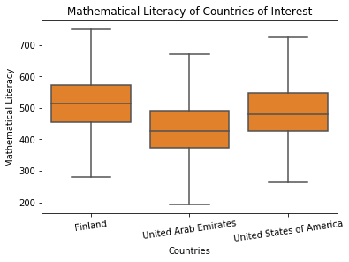

```python
base_color = sns.color_palette()[1];
sns.boxplot(data=df, x='COUNTRY', y='PV1MATH', color=base_color,
            order=['Finland', 'United Arab Emirates', 'United States of America'], showfliers=False);

plt.title('Mathematical Literacy of Countries of Interest');
plt.xlabel('Countries');
plt.ylabel('Mathematical Literacy');
plt.xticks(rotation=8);
```

The boxplot shows that Finland's mathematical literacy is the highest as it is expected. Also, USA shows higher mathematical literacy than UAE. Let us try to investigate why would that be case.

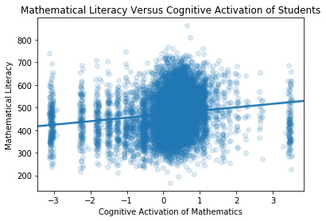

```python
sns.regplot(data=df, y='PV1MATH', x='COGNITIVEACTIV', fit_reg = True,
           x_jitter = 0.05, y_jitter = 0.05, scatter_kws = {'alpha' : 0.15});

plt.title('Mathematical Literacy Versus Cognitive Activation of Students');
plt.xlabel('Cognitive Activation of Mathematics');
plt.ylabel('Mathematical Literacy');
```

We can observe a positive relationship between cognitive activation of students in mathematics and mathematical literacy. Would that relationship hold true for all the countries of interest?

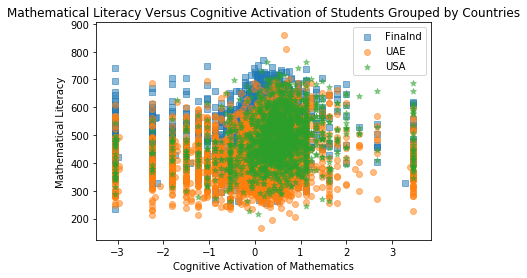

```python
country_markers = [['Finland', 's'],
                   ['United Arab Emirates', 'o'],
                  ['United States of America', '*']]

for country, marker in country_markers:
    df_prop = df[df['COUNTRY'] == country]
    plt.scatter(data = df_prop, x = 'COGNITIVEACTIV', y = 'PV1MATH', marker = marker, alpha=0.5)

plt.legend(['Finalnd', 'UAE','USA']);
plt.title('Mathematical Literacy Versus Cognitive Activation of Students Grouped by Countries');
plt.xlabel('Cognitive Activation of Mathematics');
plt.ylabel('Mathematical Literacy');
```

As observed, the positive relationship between cognitive activation of students in mathematics and mathematical literacy holds true for seperate countries. Interestingly, the ranking of the countries' mathematical literacy is found to be true with the cognitive activation in the countries. All this is great, but the question remains: "What can the UAE or the USA do so that they achieve mathematical litracy of Finalnd?"

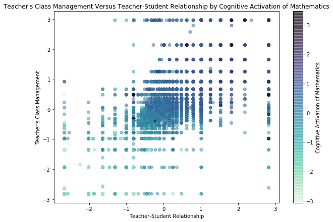

```python
plt.figure(figsize=[10,7])

plt.scatter(data=df, x='TEACHSTUDRELAT', y='TEACHERCLASSMANAG', c='COGNITIVEACTIV', cmap = 'mako_r', alpha= 0.5);

plt.colorbar(label = 'Cognitive Activation of Mathematics');
plt.title("Teacher's Class Management Versus Teacher-Student Relationship by Cognitive Activation of Mathematics", loc='center');
plt.xlabel('Teacher-Student Relationship');
plt.ylabel("Teacher's Class Management");
```

There is observations for this plot that helps understand how can a country improves it's student's cognitive activation of mathematics that in return increases mathematical literacy:

1) If teacher's class management is high and teacher-student relationship is low, and vice versa, the student's cognitive activation does not show a clear positive or negative relationship

2) If both teacher's class management and teacher-student relationship are high, then student's cognitive activation is high

3) If both teacher's class management and teacher-student relationship are low, then student's cognitive activation is low

Thus, we can recommend working on increasing the teacher's class management efforts and a better teacher-student relationship in order to increase the student's cognitive activation of mathematics, which in return increases the mathematical literacy of the students.